# RNA-seq Analysis in R

## Challenge 2

> 1. Repeat the same heatmap as above, but for the top 100 most differentially-expressed genes
> 2. Change the plot so that gene names are displayed rather than Entrez IDs

## Retrieving Genomic Locations

It might seem natural to add genomic locations to our annotation table, and possibly a bit odd that the `org.Mm.eg.db` package does not supply such mappings. In fact, there is a whole suite of package for performing this, and more-advanced queries that relate to the location of genes. These are listed on the Bioconductor [annotation page](http://bioconductor.org/packages/release/BiocViews.html#___AnnotationData) and have the prefix `TxDb.`

The package we will be using is `TxDb.Mmusculus.UCSC.mm10.knownGene`. Packages are available for other organisms and genome builds. It is even possible to *build your own database* if one does not exist. See `vignette("GenomicFeatures")` for details

```r
source("http://www.bioconductor.org/biocLite.R")
biocLite("TxDb.Mmusculus.UCSC.mm10.knownGene")

## For Humans
biocLite("TxDb.Hsapiens.UCSC.hg19.knownGene")
```

We load the library in the usual fashion and create a new object to save some typing. As with the `org.` packages, we can query what columns are available with `columns`,

```r
library(TxDb.Mmusculus.UCSC.mm10.knownGene)
tx <- TxDb.Mmusculus.UCSC.mm10.knownGene
columns(tx)
```

```
 [1] "CDSCHROM"   "CDSEND"     "CDSID"      "CDSNAME"    "CDSSTART"   "CDSSTRAND"  "EXONCHROM"  "EXONEND"
 [9] "EXONID"     "EXONNAME"   "EXONRANK"   "EXONSTART"  "EXONSTRAND" "GENEID"     "TXCHROM"    "TXEND"
[17] "TXID"       "TXNAME"     "TXSTART"    "TXSTRAND"   "TXTYPE"
```

The `select` function is used in the same manner as the `org.Mm.eg.db` packages.

## Challenge 3

> Use the TxDb.Mmusculus.UCSC.mm10.knownGene package to retrieve the exon coordinates for the genes `50916`, `110308`, `12293`

### Overview of GenomicRanges

One of the real strengths of the `txdb..` packages is the ability of interface with `GenomicRanges`, which is the object type used throughout Bioconductor [to manipulate Genomic Intervals](https://www.ncbi.nlm.nih.gov/pmc/articles/PMC3738458/pdf/pcbi.1003118.pdf).

These object types permit us to perform common operations on intervals such as overlapping and counting. We can define the chromosome, start and end position of each region (also strand too, but not shown here).

```r
library(GenomicRanges)
simple.range <-GRanges("1", IRanges(start=1000,end=2000))
simple.range
```

```
GRanges object with 1 range and 0 metadata columns:
      seqnames    ranges strand
         <Rle> <IRanges>  <Rle>
  [1]        1 1000-2000      *
  -------
  seqinfo: 1 sequence from an unspecified genome; no seqlengths
```

We don’t have to have all our ranges located on the same chromosome

```r
chrs <- c("chr13", "chr15","chr5")
start <- c(73000000, 101000000, 15000000)
end <- c(74000000,102000000, 16000000)
my.ranges <- GRanges(rep(chrs,3),
                     IRanges(start=rep(start,each=3),
                             end = rep(end,each=3))
)
```

There are a number of useful functions for calculating properties of the data (such as *coverage* or sorting). Not so much for RNA-seq analysis, but `GenomicRanges` are used throughout Bioconductor for the analysis of NGS data.

```r
keys <- c("50916","110308","12293")
genePos <- select(tx, keys=keys,
       keytype = "GENEID",
       columns=c("EXONCHROM","EXONSTART","EXONEND")
      )
geneRanges <- GRanges(genePos$EXONCHROM, IRanges(genePos$EXONSTART,genePos$EXONEND), GENEID=genePos$GENEID)
geneRanges
```

```
GRanges object with 58 ranges and 1 metadata column:
       seqnames            ranges strand |      GENEID
          <Rle>         <IRanges>  <Rle> | <character>
   [1]    chr13 73260497-73260876      * |       50916
   [2]    chr13 73264848-73264979      * |       50916
   [3]    chr13 73265458-73265709      * |       50916
   [4]    chr13 73266596-73266708      * |       50916
   [5]    chr13 73267504-73267832      * |       50916
   ...      ...               ...    ... .         ...
  [54]     chr5 16370558-16374511      * |       12293
  [55]     chr5 16341990-16342010      * |       12293
  [56]     chr5 16326327-16326383      * |       12293
  [57]     chr5 16322539-16322595      * |       12293
  [58]     chr5 16267376-16268604      * |       12293
  -------
  seqinfo: 3 sequences from an unspecified genome; no seqlengths
```

```r
findOverlaps(my.ranges,geneRanges)
```

```
Hits object with 16 hits and 0 metadata columns:
       queryHits subjectHits
       <integer>   <integer>
   [1]         1           1
   [2]         1           2
   [3]         1           3
   [4]         1           4
   [5]         1           5
   ...       ...         ...
  [12]         5          12
  [13]         5          13
  [14]         5          14
  [15]         5          15
  [16]         9          16
  -------
  queryLength: 9 / subjectLength: 58
```

```r
seqlevelsStyle(geneRanges)
```

```
[1] "UCSC"
```

```r
seqlevelsStyle(simple.range)
```

```
[1] "NCBI"    "Ensembl" "MSU6"    "AGPvF"
```

## Retrieving Gene Coordinates as GenomicRanges

As we saw above, it is quite straightforward to translate the output of a `select` query into a `GenomicFeatures` object. However, several convenience functions exist to retrieve the structure of every gene for a given organism in one object.

The output of `exonsBy` is a list, where each item in the list is the exon co-ordinates of a particular gene.

```r
exo <- exonsBy(tx,"gene")
exo
```

```
GRangesList object of length 24116:
$100009600
GRanges object with 7 ranges and 2 metadata columns:
      seqnames            ranges strand |   exon_id   exon_name
         <Rle>         <IRanges>  <Rle> | <integer> <character>
  [1]     chr9 21062393-21062717      - |    134539        <NA>
  [2]     chr9 21062894-21062987      - |    134540        <NA>
  [3]     chr9 21063314-21063396      - |    134541        <NA>
  [4]     chr9 21066024-21066377      - |    134542        <NA>
  [5]     chr9 21066940-21067925      - |    134543        <NA>
  [6]     chr9 21068030-21068117      - |    134544        <NA>
  [7]     chr9 21073075-21075496      - |    134546        <NA>

$100009609
GRanges object with 6 ranges and 2 metadata columns:
      seqnames            ranges strand | exon_id exon_name
  [1]     chr7 84940169-84941088      - |  109989      <NA>
  [2]     chr7 84943141-84943264      - |  109990      <NA>
  [3]     chr7 84943504-84943722      - |  109991      <NA>
  [4]     chr7 84946200-84947000      - |  109992      <NA>
  [5]     chr7 84947372-84947651      - |  109993      <NA>
  [6]     chr7 84963816-84964009      - |  109994      <NA>

$100009614
GRanges object with 1 range and 2 metadata columns:
      seqnames            ranges strand | exon_id exon_name
  [1]    chr10 77711446-77712009      + |  143986      <NA>

...
<24113 more elements>
-------
seqinfo: 66 sequences (1 circular) from mm10 genome
```

To access the structure of a particular gene, we can use the `[[` syntax with the name of the gene (Entrez gene ID) within quote marks. If we wanted to whole region that the gene spans we could use the `range` function.

```r
exo[["110308"]]
```

```
GRanges object with 9 ranges and 2 metadata columns:
      seqnames              ranges strand |   exon_id   exon_name
         <Rle>           <IRanges>  <Rle> | <integer> <character>
  [1]    chr15 101707070-101707722      - |    211486        <NA>
  [2]    chr15 101708117-101708151      - |    211487        <NA>
  [3]    chr15 101708876-101709096      - |    211488        <NA>
  [4]    chr15 101709753-101709878      - |    211489        <NA>
  [5]    chr15 101710251-101710415      - |    211490        <NA>
  [6]    chr15 101710536-101710631      - |    211491        <NA>
  [7]    chr15 101710739-101710799      - |    211492        <NA>
  [8]    chr15 101711529-101711743      - |    211493        <NA>
  [9]    chr15 101712274-101712891      - |    211494        <NA>
  -------
  seqinfo: 66 sequences (1 circular) from mm10 genome
```

```r
range(exo[["110308"]])
```

```
GRanges object with 1 range and 0 metadata columns:
      seqnames              ranges strand
         <Rle>           <IRanges>  <Rle>
  [1]    chr15 101707070-101712891      -
  -------
  seqinfo: 66 sequences (1 circular) from mm10 genome
```

## Exporting tracks

It is also possible to save the results of a Bioconductor analysis in a browser to enable interactive analysis and integration with other data types, or sharing with collaborators. For instance, we might want a browser track to indicate where our differentially-expressed genes are located. We shall use the `bed` format to display these locations. We will annotate the ranges with information from our analysis such as the fold-change and significance.

First we create a data frame for just the DE genes.

```r
sigGenes <- results.annotated[which(results.annotated$padj < 0.05),]
sigGenes
```

```
DataFrame with 2337 rows and 9 columns
                  baseMean     log2FoldChange             lfcSE              stat               pvalue
                 <numeric>          <numeric>         <numeric>         <numeric>            <numeric>
67111     306.660254651116  -2.23324872926005  0.15788538108878 -14.1447467388021 2.01239829443001e-45
170459    398.929351766412  -2.52810779567362 0.218040292013263 -11.5946817550576 4.38492517229431e-31
100042069 2933.24847370486    1.2350233918969 0.111560608993607  11.0704253323651 1.74570071259733e-28
77697     207.871696302787  -1.63202801130171 0.152928644173235 -10.6718268518289 1.37888326090268e-26
12704     55.9983320945389   3.18546655562673 0.298956821338253  10.6552730302901 1.64760487478274e-26
...                    ...                ...               ...               ...                  ...
208285     332.34914702122 -0.587642833733413 0.219103410977093 -2.68203416420044  0.00731759862724367
223658    1174.44826896886  -1.04517426055409 0.389814522255067 -2.68120914148551    0.007335665362164
210106    985.001013155077  0.681452584304752 0.254180759557122  2.68097626858971  0.00734077215921741
319277    734.308093865964 -0.323874885297686  0.12083498040902 -2.68030734313348  0.00735545913566679
18793     2405.06307719028   1.09279320052128 0.407860293289347  2.67933215981389  0.00737691756224098
                          padj    ENTREZID      SYMBOL
```

[output cut: 25 more lines]

At the moment, we have a GenomicFeatures object that represents every exon. However, we do not need this level of granularity for the bed output, so we will collapse to a single region for each gene. First we the `range` function to obtain a single range for every gene and tranform to a more convenient object with `unlist`.

```r
exoRanges <- unlist(range(exo))
sigRegions <- exoRanges[na.omit(match(sigGenes$ENTREZID, names(exoRanges)))]
sigRegions
```

```
GRanges object with 2220 ranges and 0 metadata columns:
         seqnames              ranges strand
            <Rle>           <IRanges>  <Rle>
   67111     chr5   92257660-92278181      -
  170459    chr18   33201421-33213816      -
   77697     chr5 114431034-114444027      -
   12704     chr5 115845278-116006341      +
   69237    chr13     8972478-8996012      -
     ...      ...                 ...    ...
  208285    chr17   32506462-32528894      +
  223658    chr15   76380513-76453039      +
  210106    chr13   69497959-69533864      -
  319277    chr10   83543941-83596473      +
   18793     chr7   24462483-24475968      +
  -------
  seqinfo: 66 sequences (1 circular) from mm10 genome
```

Rather than just representing the genomic locations, the .bed format is also able to colour each range according to some property of the analysis (e.g. direction and magnitude of change) to help highlight particular regions of interest. A score can also be displayed when a particular region is clicked-on. A useful propery of GenomicRanges is that we can attach *metadata* to each range using the `mcols` function. The metadata can be supplied in the form of a data frame.

```r
mcols(sigRegions) <- sigGenes[match(names(sigRegions), rownames(sigGenes)),]
sigRegions
```

```
GRanges object with 2220 ranges and 9 metadata columns:
         seqnames              ranges strand |         baseMean     log2FoldChange              lfcSE
            <Rle>           <IRanges>  <Rle> |        <numeric>          <numeric>          <numeric>
   67111     chr5   92257660-92278181      - | 306.660254651116  -2.23324872926005   0.15788538108878
  170459    chr18   33201421-33213816      - | 398.929351766412  -2.52810779567362  0.218040292013263
   77697     chr5 114431034-114444027      - | 207.871696302787  -1.63202801130171  0.152928644173235
   12704     chr5 115845278-116006341      + | 55.9983320945389   3.18546655562673  0.298956821338253
   69237    chr13     8972478-8996012      - | 1551.26575732965  0.743642725102713 0.0704083771229651
     ...      ...                 ...    ... .              ...                ...                ...
  208285    chr17   32506462-32528894      + |  332.34914702122 -0.587642833733413  0.219103410977093
  223658    chr15   76380513-76453039      + | 1174.44826896886  -1.04517426055409  0.389814522255067
  210106    chr13   69497959-69533864      - | 985.001013155077  0.681452584304752  0.254180759557122
  319277    chr10   83543941-83596473      + | 734.308093865964 -0.323874885297686   0.12083498040902
   18793     chr7   24462483-24475968      + | 2405.06307719028   1.09279320052128  0.407860293289347
                      stat               pvalue                 padj    ENTREZID      SYMBOL
```

[output cut: 27 more lines]

The metadata we have added can also by used as a means to interrogate the ranges; as if the data were contained in a data frame.

```r
sigRegions[order(sigRegions$log2FoldChange,decreasing = TRUE)]
```

```
GRanges object with 2220 ranges and 9 metadata columns:
            seqnames              ranges strand |         baseMean    log2FoldChange            lfcSE
               <Rle>           <IRanges>  <Rle> |        <numeric>         <numeric>        <numeric>
  100043899     chr2 163492318-163502612      + | 115.018608974264  10.4496528532166 1.94759862509401
      12945     chr7 131032076-131121628      + | 94.1139495352103  10.1619909520401 2.01843941345328
      11839     chr5   91139599-91148432      + | 2038.61640126572  7.85214591954118 1.26088449001769
      22239     chr3 125865343-125956653      - | 51.2029361548907  7.80106105970847 1.69610082422332
     622127     chr5 145345270-145390512      + | 164.572894124796  7.69148778117651 1.76258467710848
        ...      ...                 ...    ... .              ...               ...              ...
      83492    chr15   63775971-63912297      - | 238.853117160486 -10.2286654750528 1.70475811824796
      22373    chr11     6635483-6638649      - | 389347.998755878 -10.3760886139636 1.61087969643594
     381925     chr7 129257094-129391307      + | 65.1966451704498 -10.3810988970626 1.95217133564164
      14663    chr15 103562760-103565081      - |  522485.92725077 -11.1101256966101 1.52283676609328
      12992     chr5   87808121-87824421      + | 26762.9504028503 -11.3722971128835 1.45632445086782
                         stat               pvalue                 padj    ENTREZID      SYMBOL
```

[output cut: 27 more lines]

For visualisation purposes, we are going to restrict the data to genes that are located on chromosomes 1 to 19 and the sex chromosomes. This can be done with the `keepSeqLevels` function.

```r
seqlevels(sigRegions)
```

```
 [1] "chr1"                 "chr2"                 "chr3"                 "chr4"
 [5] "chr5"                 "chr6"                 "chr7"                 "chr8"
 [9] "chr9"                 "chr10"                "chr11"                "chr12"
[13] "chr13"                "chr14"                "chr15"                "chr16"
[17] "chr17"                "chr18"                "chr19"                "chrX"
[21] "chrY"                 "chrM"                 "chr1_GL456210_random" "chr1_GL456211_random"
[25] "chr1_GL456212_random" "chr1_GL456213_random" "chr1_GL456221_random" "chr4_GL456216_random"
[29] "chr4_GL456350_random" "chr4_JH584292_random" "chr4_JH584293_random" "chr4_JH584294_random"
[33] "chr4_JH584295_random" "chr5_GL456354_random" "chr5_JH584296_random" "chr5_JH584297_random"
[37] "chr5_JH584298_random" "chr5_JH584299_random" "chr7_GL456219_random" "chrX_GL456233_random"
[41] "chrY_JH584300_random" "chrY_JH584301_random" "chrY_JH584302_random" "chrY_JH584303_random"
[45] "chrUn_GL456239"       "chrUn_GL456359"       "chrUn_GL456360"       "chrUn_GL456366"
[49] "chrUn_GL456367"       "chrUn_GL456368"       "chrUn_GL456370"       "chrUn_GL456372"
[53] "chrUn_GL456378"       "chrUn_GL456379"       "chrUn_GL456381"       "chrUn_GL456382"
[57] "chrUn_GL456383"       "chrUn_GL456385"       "chrUn_GL456387"       "chrUn_GL456389"
[61] "chrUn_GL456390"       "chrUn_GL456392"       "chrUn_GL456393"       "chrUn_GL456394"
[65] "chrUn_GL456396"       "chrUn_JH584304"
```

```r
sigRegions <- keepSeqlevels(sigRegions, paste0("chr", c(1:19,"X","Y")),pruning.mode = "coarse")
```

We will now create a score from the p-values that will displayed under each region, and colour scheme for the regions based on the fold-change. For the score we can use the $-log_{10}$ of the adjusted p-value as before

```r
Score <- -log10(sigRegions$padj)
```

`colorRampPalette` is a useful function in base R for constructing a palette between two extremes. **When choosing colour palettes, make sure they are colour blind friendly**. The red / green colour scheme traditionally-applied to microarrays is a *bad* choice.

We will also truncate the fold-changes to between -5 and 5 to and divide this range into 10 equal bins

```r
rbPal <-colorRampPalette(c("red", "blue"))
logfc <- pmax(sigRegions$log2FoldChange, -5)
logfc <- pmin(logfc , 5)
Col <- rbPal(10)[as.numeric(cut(logfc, breaks = 10))]
```

Now we can export the signifcant results from the DE analysis as a `.bed` track using `rtracklayer`. You can load the resulting file in IGV, if you wish.

```r
mcols(sigRegions)$score <- Score
mcols(sigRegions)$itemRgb <- Col
sigRegions
```

```
GRanges object with 2220 ranges and 11 metadata columns:
         seqnames              ranges strand |         baseMean     log2FoldChange              lfcSE
            <Rle>           <IRanges>  <Rle> |        <numeric>          <numeric>          <numeric>
   67111     chr5   92257660-92278181      - | 306.660254651116  -2.23324872926005   0.15788538108878
  170459    chr18   33201421-33213816      - | 398.929351766412  -2.52810779567362  0.218040292013263
   77697     chr5 114431034-114444027      - | 207.871696302787  -1.63202801130171  0.152928644173235
   12704     chr5 115845278-116006341      + | 55.9983320945389   3.18546655562673  0.298956821338253
   69237    chr13     8972478-8996012      - | 1551.26575732965  0.743642725102713 0.0704083771229651
     ...      ...                 ...    ... .              ...                ...                ...
  208285    chr17   32506462-32528894      + |  332.34914702122 -0.587642833733413  0.219103410977093
  223658    chr15   76380513-76453039      + | 1174.44826896886  -1.04517426055409  0.389814522255067
  210106    chr13   69497959-69533864      - | 985.001013155077  0.681452584304752  0.254180759557122
  319277    chr10   83543941-83596473      + | 734.308093865964 -0.323874885297686   0.12083498040902
   18793     chr7   24462483-24475968      + | 2405.06307719028   1.09279320052128  0.407860293289347
                      stat               pvalue                 padj    ENTREZID      SYMBOL
```

[output cut: 27 more lines]

```r
library(rtracklayer)
export(sigRegions , con = "topHits.bed")
```

## Brief Introduction to ggplot2

The [`ggplot2`](http://ggplot2.tidyverse.org/) package has emerged as an attractive alternative to the traditional plots provided by base R. A full overview of all capabilities of the package is available from the [cheatsheet](https://www.rstudio.com/wp-content/uploads/2015/03/ggplot2-cheatsheet.pdf).

A simple scatter plot, equivalent to `plotMA` from before, can be generated as follows:-

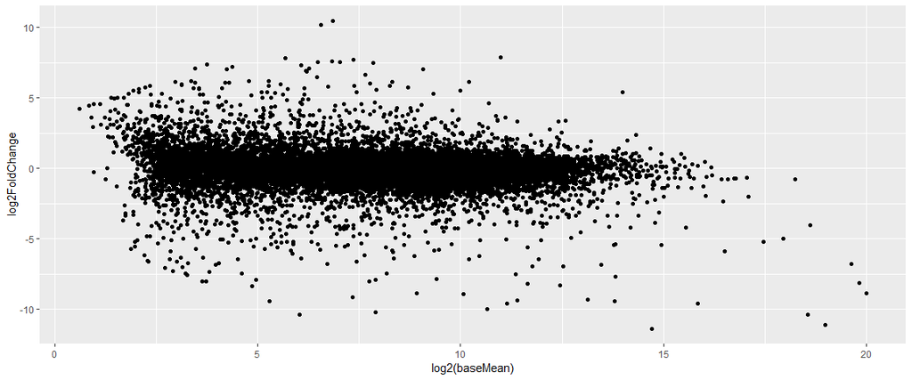

```r
library(ggplot2)
df <- as.data.frame(results.ordered)
ggplot(df, aes(x = log2(baseMean), y=log2FoldChange)) + geom_point()
```

The real advantage of `ggplot2` is the ability to change the appearance of our plot by mapping other variables to aspects of the plot. For example, we could colour the points based on a p-value cut-off. The colours are automatically chosen by `ggplot2`, but we can specifiy particular values.

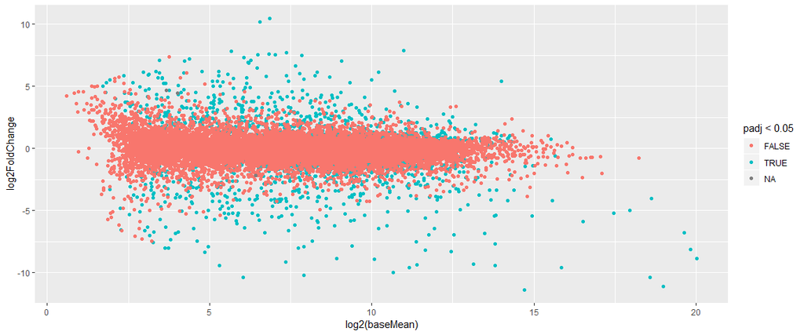

```r
ggplot(df, aes(x = log2(baseMean), y=log2FoldChange,col=padj<0.05)) + geom_point()
```

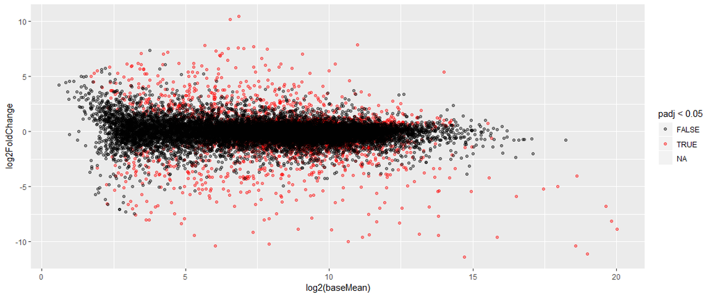

```r
ggplot(df, aes(x = log2(baseMean), y=log2FoldChange,col=padj<0.05)) + geom_point(alpha=0.4) +  scale_colour_manual(values=c("black","red"))
```

The volcano plot can be constructed in a similar manner

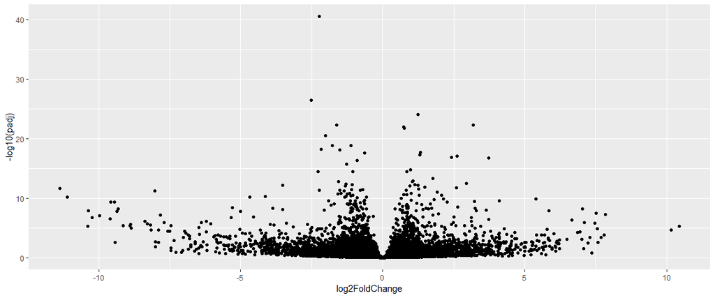

```r
ggplot(df, aes(x = log2FoldChange, y=-log10(padj))) + geom_point()
```

The `plotCounts` function that we saw earlier can be adjusted to return the data associated with the plot, which in-turn can be passed to a `ggplot2` function for customisable plots.

```r
plot_data <- plotCounts(dds, "94352",intgroup = c("CellType","Status"),returnData = TRUE)
plot_data
```

|  | count | CellType | Status |
| --- | --- | --- | --- |
| MCL1.DG | 39.95808 | basal | virgin |
| MCL1.DH | 96.06628 | basal | virgin |
| MCL1.DI | 589.17118 | basal | pregnant |
| MCL1.DJ | 568.66037 | basal | pregnant |
| MCL1.DK | 1632.29950 | basal | lactate |
| MCL1.DL | 966.58346 | basal | lactate |
| MCL1.LA | 24.69104 | luminal | virgin |
| MCL1.LB | 13.72736 | luminal | virgin |
| MCL1.LC | 16.01019 | luminal | pregnant |
| MCL1.LD | 11.38164 | luminal | pregnant |

[output cut: 2 more lines]

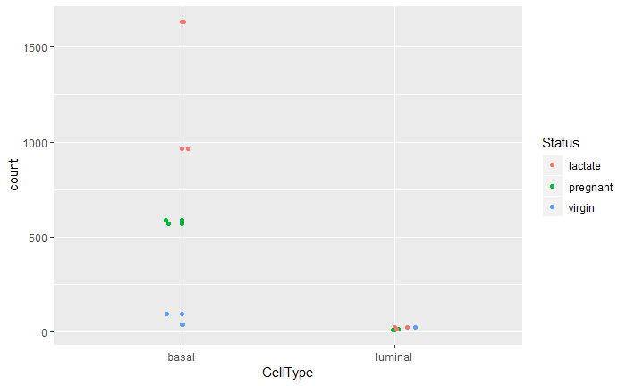

```r
ggplot(plot_data, aes(x = CellType,y=count,col=Status)) + geom_point() + geom_jitter(width = 0.1)
```

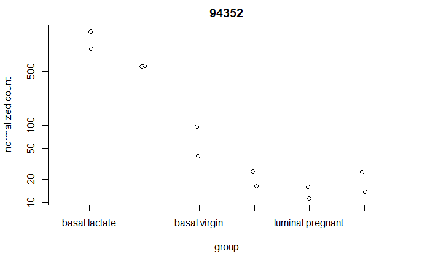

```r
plot_data <- plotCounts(dds, "94352",intgroup = c("CellType","Status"))
```